# Assignment 2 - Decision Tree Model

Marketing 2

19 June 2026

# 1. Introduction

This R Markdown document presents the Decision Tree model used to predict customer recommendation behaviour for Gelugor Fashion Store. The target variable is `recommend_index`, where customers are classified as either `Recommend` or `Not_Recommend`. The `Not_Recommend` class is treated as the positive class because it represents loyalty-risk customers who may require targeted improvement actions.

# 2. Load Dataset

```r
final_ml_dataset <- read_csv("final_ml_dataset.csv")

dim(final_ml_dataset)
```

```
## [1] 22627   175
```

```r
str(final_ml_dataset)
```

```
## spc_tbl_ [22,627 × 175] (S3: spec_tbl_df/tbl_df/tbl/data.frame)
##  $ recommend_index     : num [1:22627] 1 1 0 1 1 1 1 1 1 1 ...
##  $ rating              : num [1:22627] 5 5 1 5 5 4 5 5 5 5 ...
##  $ sentiment_score     : num [1:22627] 1 3 1 4 -1 4 8 1 5 8 ...
##  $ age                 : num [1:22627] 40 62 47 45 37 43 79 34 49 49 ...
##  $ alike_feedback_count: num [1:22627] 0 12 3 0 0 0 4 2 4 0 ...
##  $ age_group           : chr [1:22627] "middle" "senior" "middle" "middle" ...
##  $ department_name     : chr [1:22627] "Bottoms" "Tops" "Bottoms" "Bottoms" ...
##  $ class_name          : chr [1:22627] "Jeans" "Blouses" "Skirts" "Pants" ...
##  $ feedback_count_group: num [1:22627] 1 1 1 1 1 1 1 1 1 1 ...
##  $ division_name       : chr [1:22627] "General" "General Petite" "General Petite" "General Petite" ...
##  $ amaze               : num [1:22627] 1 0 0 0 0 0 0 0 0 0 ...
##  $ fit                 : num [1:22627] 1 1 0 1 1 0 1 0 0 0 ...
##  $ jeans               : num [1:22627] 1 0 0 0 0 1 0 0 0 0 ...
##  $ pair                : num [1:22627] 1 0 0 0 0 0 0 0 0 0 ...
##  $ purchase            : num [1:22627] 1 0 0 0 1 0 0 0 0 0 ...
##  $ color               : num [1:22627] 0 1 0 1 0 1 1 0 0 0 ...
##  $ fall                : num [1:22627] 0 1 0 0 0 0 0 0 0 0 ...
##  $ flatter             : num [1:22627] 0 1 0 0 0 0 0 0 0 0 ...
##  $ lovely              : num [1:22627] 0 1 0 0 0 0 0 0 0 1 ...
##  $ model               : num [1:22627] 0 1 0 0 0 0 0 0 0 0 ...
##  $ photo               : num [1:22627] 0 1 0 0 0 0 0 0 0 0 ...
##  $ shame               : num [1:22627] 0 1 0 0 0 0 0 0 0 0 ...
##  $ soft                : num [1:22627] 0 1 0 0 0 0 1 0 0 1 ...
##  $ true                : num [1:22627] 0 1 0 0 0 0 1 0 0 0 ...
##  $ unique              : num [1:22627] 0 1 0 0 0 0 1 1 0 0 ...
##  $ winter              : num [1:22627] 0 1 0 0 0 0 0 0 0 0 ...
##  $ design              : num [1:22627] 0 0 1 0 0 0 0 0 0 0 ...
##  $ love                : num [1:22627] 0 0 1 1 1 1 1 0 1 1 ...
##  $ meh                 : num [1:22627] 0 0 1 0 0 0 0 0 0 0 ...
##  $ black               : num [1:22627] 0 0 0 1 0 0 0 0 0 0 ...
##  $ buy                 : num [1:22627] 0 0 0 1 0 0 0 0 1 0 ...
##  $ perfect             : num [1:22627] 0 0 0 1 0 0 0 0 0 0 ...
##  $ size                : num [1:22627] 0 0 0 1 1 0 1 0 0 1 ...
##  $ slightly            : num [1:22627] 0 0 0 1 0 0 0 0 0 0 ...
##  $ look                : num [1:22627] 0 0 0 0 1 0 0 0 0 0 ...
##  $ odd                 : num [1:22627] 0 0 0 0 1 0 0 0 0 0 ...
##  $ piece               : num [1:22627] 0 0 0 0 1 1 0 0 0 0 ...
##  $ simple              : num [1:22627] 0 0 0 0 0 1 0 0 0 0 ...
##  $ staple              : num [1:22627] 0 0 0 0 0 1 0 0 0 0 ...
```

[output cut: 225 more lines]

[output not shown]

```r
head(final_ml_dataset)
```

```
## # A tibble: 6 × 175
##   recommend_index rating sentiment_score   age alike_feedback_count age_group
##             <dbl>  <dbl>           <dbl> <dbl>                <dbl> <chr>
## 1               1      5               1    40                    0 middle
## 2               1      5               3    62                   12 senior
## 3               0      1               1    47                    3 middle
## 4               1      5               4    45                    0 middle
## 5               1      5              -1    37                    0 middle
## 6               1      4               4    43                    0 middle
## # ℹ 169 more variables: department_name <chr>, class_name <chr>,
## #   feedback_count_group <dbl>, division_name <chr>, amaze <dbl>, fit <dbl>,
## #   jeans <dbl>, pair <dbl>, purchase <dbl>, color <dbl>, fall <dbl>,
## #   flatter <dbl>, lovely <dbl>, model <dbl>, photo <dbl>, shame <dbl>,
## #   soft <dbl>, true <dbl>, unique <dbl>, winter <dbl>, design <dbl>,
## #   love <dbl>, meh <dbl>, black <dbl>, buy <dbl>, perfect <dbl>, size <dbl>,
## #   slightly <dbl>, look <dbl>, odd <dbl>, piece <dbl>, simple <dbl>, …
```

## Target Distribution

```r
table(final_ml_dataset$recommend_index)
```

```
##
##     0     1
##  4101 18526
```

```r
prop.table(table(final_ml_dataset$recommend_index))
```

```
##
##         0         1
## 0.1812436 0.8187564
```

# 3. Data Preparation for Modelling

The target variable is converted into a factor with two classes: `Not_Recommend` and `Recommend`. Character variables are also converted into factors so that they can be used properly in the Decision Tree model.

```r
dt_data <- final_ml_dataset %>%
  mutate(
    recommend_index = factor(
      ifelse(recommend_index == 1, "Recommend", "Not_Recommend"),
      levels = c("Not_Recommend", "Recommend")
    )
  ) %>%
  mutate(
    across(where(is.character), as.factor)
  )

str(dt_data$recommend_index)
```

```
##  Factor w/ 2 levels "Not_Recommend",..: 2 2 1 2 2 2 2 2 2 2 ...
```

```r
table(dt_data$recommend_index)
```

```
##
## Not_Recommend     Recommend
##          4101         18526
```

```r
prop.table(table(dt_data$recommend_index))
```

```
##
## Not_Recommend     Recommend
##     0.1812436     0.8187564
```

# 4. Train-Test Split

The dataset is divided into 80% training data and 20% testing data. The training set is used to train the Decision Tree model, while the test set is used to evaluate model performance on unseen data.

```r
set.seed(123)

train_index <- createDataPartition(
  dt_data$recommend_index,
  p = 0.8,
  list = FALSE
)

train_data <- dt_data[train_index, ]
test_data  <- dt_data[-train_index, ]

dim(train_data)
```

```
## [1] 18102   175
```

```r
dim(test_data)
```

```
## [1] 4525  175
```

# 5. Decision Tree Parameter Tuning

A 10-fold cross-validation method is used to tune the Decision Tree model. The complexity parameter `cp` is tested from 0.001 to 0.05. The model is optimized based on ROC because AUC is useful for evaluating classification separability.

```r
dt_control <- trainControl(
  method = "cv",
  number = 10,
  classProbs = TRUE,
  summaryFunction = twoClassSummary,
  savePredictions = "final"
)

dt_grid <- expand.grid(
  cp = seq(0.001, 0.05, by = 0.001)
)

set.seed(123)

dt_model <- train(
  recommend_index ~ .,
  data = train_data,
  method = "rpart",
  metric = "ROC",
  trControl = dt_control,
  tuneGrid = dt_grid
)

print(dt_model)
```

```
## CART
##
## 18102 samples
##   174 predictor
##     2 classes: 'Not_Recommend', 'Recommend'
##
## No pre-processing
## Resampling: Cross-Validated (10 fold)
## Summary of sample sizes: 16291, 16292, 16292, 16292, 16291, 16292, ...
## Resampling results across tuning parameters:
##
##   cp     ROC        Sens       Spec
##   0.001  0.9578121  0.8500417  0.9547933
##   0.002  0.9594421  0.8616280  0.9515544
##   0.003  0.9559778  0.8851036  0.9451441
##   0.004  0.9521732  0.9097867  0.9395440
##   0.005  0.9480450  0.9210672  0.9365749
##   0.006  0.9410041  0.9518422  0.9301659
##   0.007  0.9410041  0.9518422  0.9301659
##   0.008  0.9410041  0.9518422  0.9301659
##   0.009  0.9410041  0.9518422  0.9301659
##   0.010  0.9410041  0.9518422  0.9301659
##   0.011  0.9410041  0.9518422  0.9301659
##   0.012  0.9410041  0.9518422  0.9301659
##   0.013  0.9410041  0.9518422  0.9301659
##   0.014  0.9410041  0.9518422  0.9301659
##   0.015  0.9410041  0.9518422  0.9301659
##   0.016  0.9410041  0.9518422  0.9301659
##   0.017  0.9410041  0.9518422  0.9301659
##   0.018  0.9410041  0.9518422  0.9301659
##   0.019  0.9410041  0.9518422  0.9301659
##   0.020  0.9410041  0.9518422  0.9301659
##   0.021  0.9410041  0.9518422  0.9301659
##   0.022  0.9410041  0.9518422  0.9301659
##   0.023  0.9410041  0.9518422  0.9301659
##   0.024  0.9410041  0.9518422  0.9301659
##   0.025  0.9410041  0.9518422  0.9301659
##   0.026  0.9410041  0.9518422  0.9301659
##   0.027  0.9410041  0.9518422  0.9301659
##   0.028  0.9410041  0.9518422  0.9301659
```

[output cut: 10 more lines]

```
##   0.039  0.9410041  0.9518422  0.9301659
##   0.040  0.9410041  0.9518422  0.9301659
##   0.041  0.9410041  0.9518422  0.9301659
##   0.042  0.9410041  0.9518422  0.9301659
##   0.043  0.9410041  0.9518422  0.9301659
##   0.044  0.9410041  0.9518422  0.9301659
##   0.045  0.9410041  0.9518422  0.9301659
##   0.046  0.9410041  0.9518422  0.9301659
##   0.047  0.9410041  0.9518422  0.9301659
##   0.048  0.9410041  0.9518422  0.9301659
##   0.049  0.9410041  0.9518422  0.9301659
##   0.050  0.9410041  0.9518422  0.9301659
##
## ROC was used to select the optimal model using the largest value.
## The final value used for the model was cp = 0.002.
```

```r
dt_model$bestTune
```

```
##      cp
## 2 0.002
```

## Tuning Plot

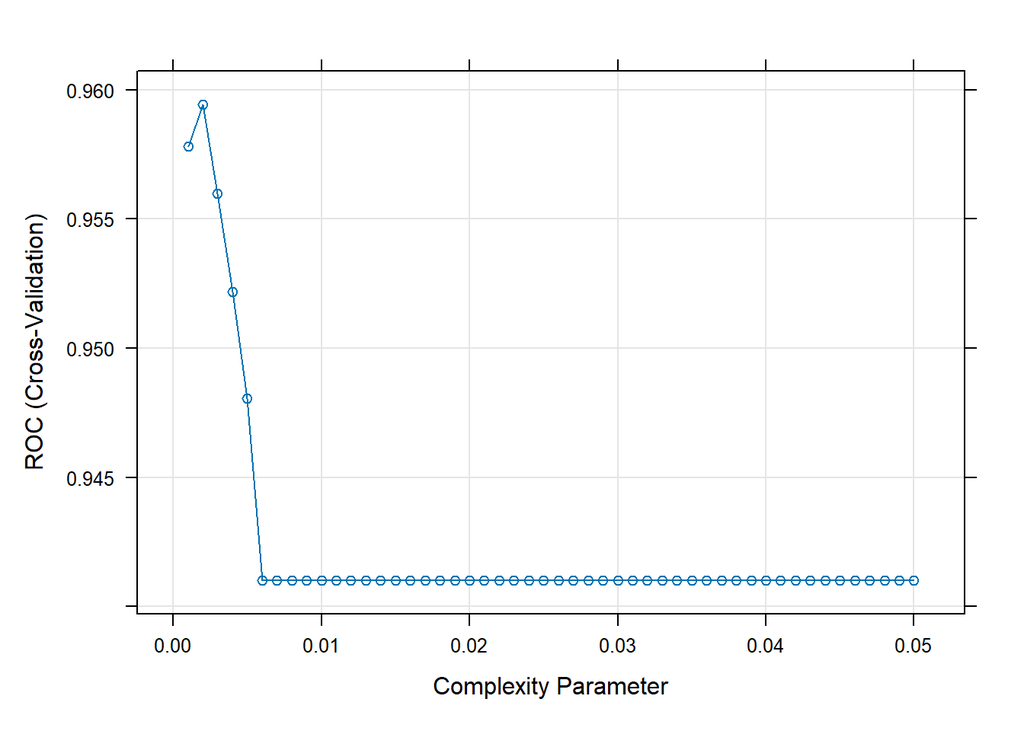

```r
plot(dt_model)
```

# 6. Final Decision Tree Plot

The final Decision Tree is visualized to show the main decision rules used by the model to classify customers as `Recommend` or `Not_Recommend`.

```r
png("DecisionTree_TreePlot.png", width = 1400, height = 900, res = 150)

rpart.plot(
  dt_model$finalModel,
  type = 2,
  extra = 104,
  fallen.leaves = TRUE,
  main = "Decision Tree for Predicting Customer Recommendation"
)

dev.off()
```

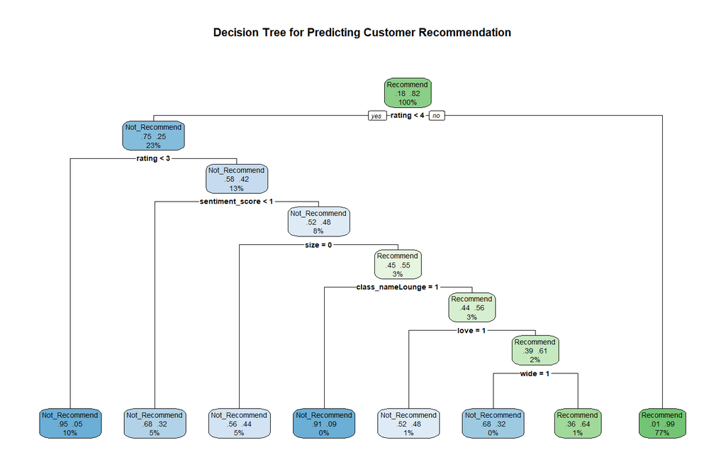

```r
knitr::include_graphics("DecisionTree_TreePlot.png")
```

# 7. Variable Importance

Variable importance is calculated to identify the most influential predictors in the Decision Tree model.

```r
dt_importance <- varImp(dt_model)$importance %>%
  rownames_to_column("Feature") %>%
  arrange(desc(Overall))

head(dt_importance, 20)
```

```
##             Feature      Overall
## 1            rating 100.00000000
## 2   sentiment_score  24.03619795
## 3            return   9.20982627
## 4        disappoint   8.49787855
## 5      unflattering   4.30295429
## 6              size   1.00551447
## 7         recommend   0.51780230
## 8              wide   0.28573501
## 9           quality   0.21186820
## 10           unique   0.19756237
## 11             love   0.18651977
## 12             look   0.17730764
## 13        maternity   0.16738679
## 14           excite   0.16181814
## 15              age   0.15602239
## 16              lie   0.13714449
## 17 class_nameLounge   0.12582450
## 18          flatter   0.08192242
## 19             pair   0.07159198
## 20            black   0.06225611
```

```r
write_csv(dt_importance, "DecisionTree_VariableImportance.csv")
```

## Variable Importance Plot

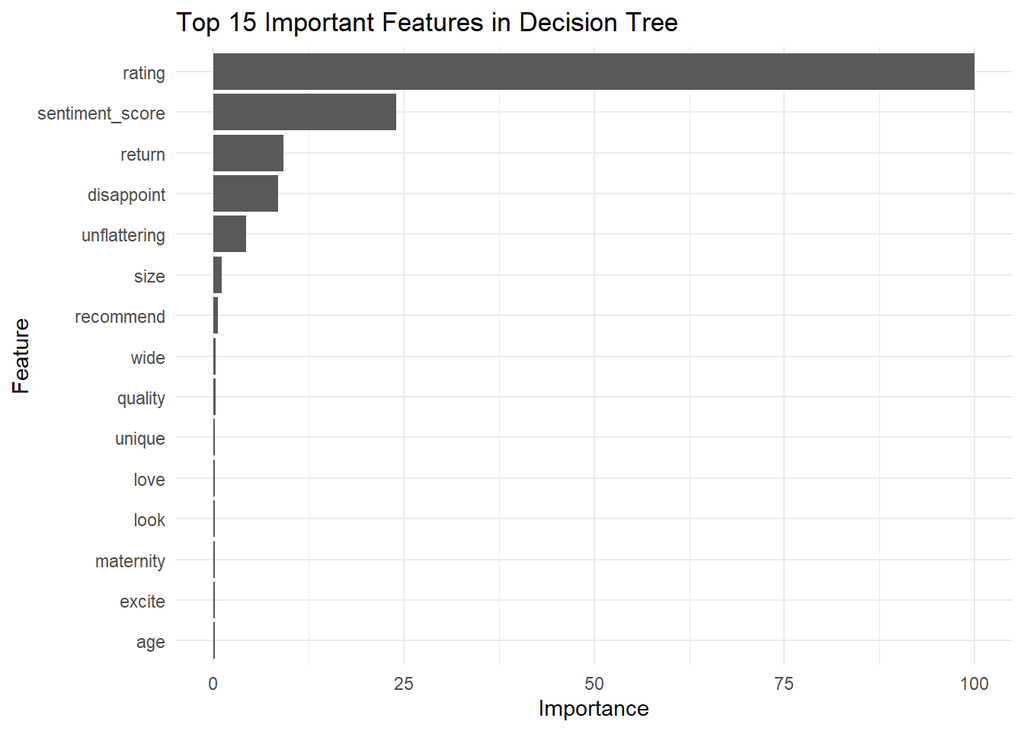

```r
top_dt_importance <- dt_importance %>%
  slice_max(order_by = Overall, n = 15)

importance_plot <- ggplot(
  top_dt_importance,
  aes(x = reorder(Feature, Overall), y = Overall)
) +
  geom_col() +
  coord_flip() +
  labs(
    title = "Top 15 Important Features in Decision Tree",
    x = "Feature",
    y = "Importance"
  ) +
  theme_minimal()

importance_plot
```

```r
ggsave(
  "DecisionTree_VariableImportance.png",
  importance_plot,
  width = 8,
  height = 5,
  dpi = 300
)
```

# 8. Test Set Prediction

The trained Decision Tree model is applied to the test set. Both predicted classes and predicted probabilities are generated.

```r
dt_pred <- predict(dt_model, newdata = test_data)
dt_prob <- predict(dt_model, newdata = test_data, type = "prob")

head(dt_pred)
```

```
## [1] Recommend     Recommend     Recommend     Recommend     Not_Recommend
## [6] Recommend
## Levels: Not_Recommend Recommend
```

```r
head(dt_prob)
```

```
##   Not_Recommend Recommend
## 1    0.01133104 0.9886690
## 2    0.01133104 0.9886690
## 3    0.01133104 0.9886690
## 4    0.01133104 0.9886690
## 5    0.67957746 0.3204225
## 6    0.01133104 0.9886690
```

# 9. Confusion Matrix

The confusion matrix is used to evaluate how many customers were correctly and incorrectly classified. The positive class is set as `Not_Recommend` because this group represents loyalty-risk customers.

```r
dt_cm <- confusionMatrix(
  data = dt_pred,
  reference = test_data$recommend_index,
  positive = "Not_Recommend"
)

print(dt_cm)
```

```
## Confusion Matrix and Statistics
##
##                Reference
## Prediction      Not_Recommend Recommend
##   Not_Recommend           768       206
##   Recommend                52      3499
##
##                Accuracy : 0.943
##                  95% CI : (0.9358, 0.9496)
##     No Information Rate : 0.8188
##     P-Value [Acc > NIR] : < 2.2e-16
##
##                   Kappa : 0.821
##
##  Mcnemar's Test P-Value : < 2.2e-16
##
##             Sensitivity : 0.9366
##             Specificity : 0.9444
##          Pos Pred Value : 0.7885
##          Neg Pred Value : 0.9854
##              Prevalence : 0.1812
##          Detection Rate : 0.1697
##    Detection Prevalence : 0.2152
##       Balanced Accuracy : 0.9405
##
##        'Positive' Class : Not_Recommend
##
```

## Save Confusion Matrix Table

```r
dt_cm_table <- as.data.frame(dt_cm$table)

dt_cm_table
```

```
##      Prediction     Reference Freq
## 1 Not_Recommend Not_Recommend  768
## 2     Recommend Not_Recommend   52
## 3 Not_Recommend     Recommend  206
## 4     Recommend     Recommend 3499
```

```r
write_csv(dt_cm_table, "DecisionTree_ConfusionMatrix_Table.csv")
```

## Confusion Matrix Heatmap

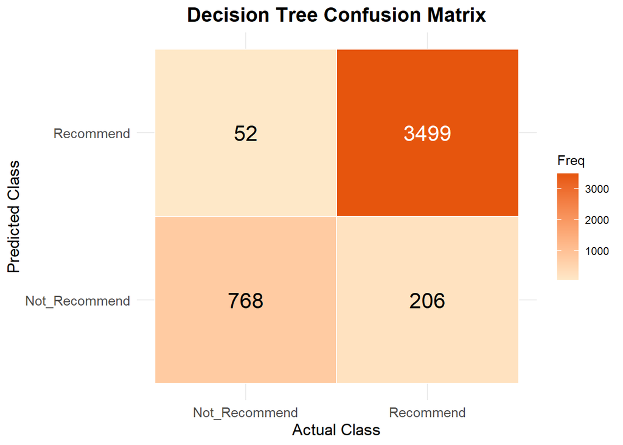

```r
cm_plot <- ggplot(dt_cm_table, aes(x = Reference, y = Prediction, fill = Freq)) +
  geom_tile(color = "white", linewidth = 0.5) +
  geom_text(
    aes(
      label = Freq,
      colour = ifelse(Freq > max(Freq) / 2, "white", "black")
    ),
    size = 6
  ) +
  scale_colour_identity() +
  scale_fill_gradient(
    low = "#FEE8C8",
    high = "#E6550D"
  ) +
  labs(
    title = "Decision Tree Confusion Matrix",
    x = "Actual Class",
    y = "Predicted Class",
    fill = "Freq"
  ) +
  theme_minimal() +
  theme(
    plot.title = element_text(size = 16, face = "bold", hjust = 0.5),
    axis.title = element_text(size = 13),
    axis.text = element_text(size = 11)
  )

cm_plot
```

```r
ggsave(
  "DecisionTree_ConfusionMatrix.png",
  cm_plot,
  width = 6,
  height = 5,
  dpi = 300
)
```

# 10. ROC Curve and AUC

The ROC curve is plotted to evaluate the model’s ability to separate `Not_Recommend` and `Recommend` customers. A higher AUC value indicates stronger classification performance.

```r
dt_roc <- roc(
  response = test_data$recommend_index,
  predictor = dt_prob$Not_Recommend,
  levels = c("Recommend", "Not_Recommend")
)

dt_auc <- auc(dt_roc)

dt_auc
```

```
## Area under the curve: 0.9674
```

## ROC Curve Plot

```r
png("DecisionTree_ROC.png", width = 1000, height = 800, res = 150)

plot(
  dt_roc,
  main = paste("Decision Tree ROC Curve, AUC =", round(dt_auc, 3))
)

dev.off()
```

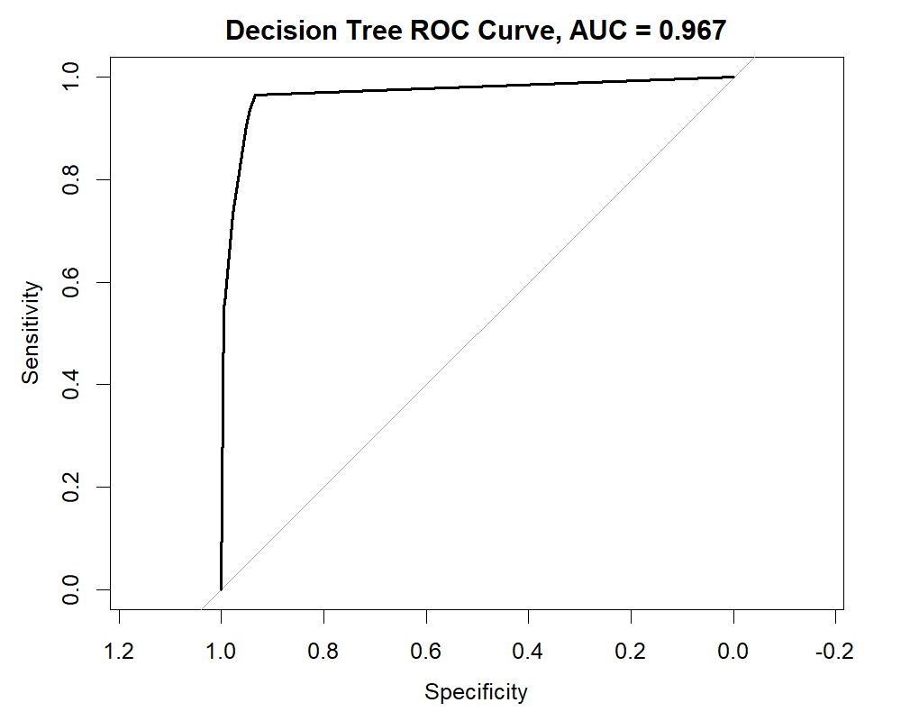

```r
knitr::include_graphics("DecisionTree_ROC.png")
```

# 11. Model Performance Metrics

The model performance is summarized using Accuracy, Kappa, Balanced Accuracy, Recall, Specificity, Precision, F1-score and AUC. Since the business focus is identifying loyalty-risk customers, Recall for `Not_Recommend` and Balanced Accuracy are especially important.

```r
dt_metrics <- data.frame(
  Model = "Decision Tree",
  Accuracy = as.numeric(dt_cm$overall["Accuracy"]),
  Kappa = as.numeric(dt_cm$overall["Kappa"]),
  Balanced_Accuracy = as.numeric(dt_cm$byClass["Balanced Accuracy"]),
  Recall_NotRecommend = as.numeric(dt_cm$byClass["Sensitivity"]),
  Specificity_Recommend = as.numeric(dt_cm$byClass["Specificity"]),
  Precision_NotRecommend = as.numeric(dt_cm$byClass["Pos Pred Value"]),
  F1_NotRecommend = as.numeric(dt_cm$byClass["F1"]),
  AUC = as.numeric(dt_auc),
  Best_cp = dt_model$bestTune$cp
)

dt_metrics
```

```
##           Model  Accuracy     Kappa Balanced_Accuracy Recall_NotRecommend
## 1 Decision Tree 0.9429834 0.8209567         0.9404924           0.9365854
##   Specificity_Recommend Precision_NotRecommend F1_NotRecommend       AUC
## 1             0.9443995               0.788501       0.8561873 0.9673952
##   Best_cp
## 1   0.002
```

```r
write_csv(dt_metrics, "DecisionTree_Metrics.csv")
```

# 12. Save Final Model

The final Decision Tree model is saved as an RDS file so that it can be reused later for prediction or model deployment.

```r
saveRDS(dt_model, "DecisionTree_Model.rds")
```

# 13. Conclusion

The Decision Tree model was trained and evaluated to predict customer recommendation behaviour. The model provides both classification results and interpretable decision rules, making it useful for identifying customers who are unlikely to recommend a product. Since `Not_Recommend` customers represent loyalty-risk customers, this model can support Gelugor Fashion Store in identifying products, review patterns, and customer segments that require targeted improvement.